# Reproducible Research: Peer Assessment 1

## Imputing missing values

1. Calculate and report the total number of missing values in the dataset (i.e. the total number of rows with NAs)

```r
totalna <- sum(is.na(activity$steps))
```

Total number of missing values in the dataset: 2304.

2. Replacing NA with mean for 5-minute interval.
3. Create a new dataset that is equal to the original dataset but with the missing data filled in.

```r
newactivity <- merge(activity,interval_avgsteps,by.x="interval", by.y="interval", all=TRUE)
newactivity$steps[is.na(newactivity$steps)] <- newactivity$steps.mean[is.na(newactivity$steps)]
```

4. Make a histogram of the total number of steps taken each day

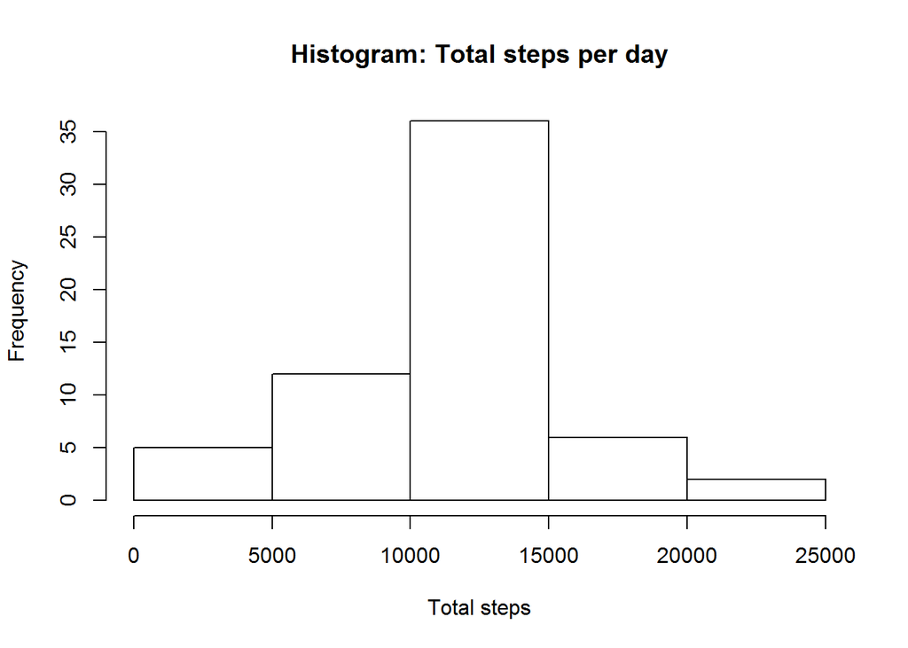

```r
total_steps_2 <- summaryBy(steps ~ date, data=newactivity, FUN=sum)
hist(total_steps_2$steps.sum, xlab = "Total steps", main = "Histogram: Total steps per day")
```

```r
newmean <- mean(total_steps_2$steps.sum)
newmedian <- median(total_steps_2$steps.sum)
```

## Are there differences in activity patterns between weekdays and weekends?

1.Create a new factor variable in the dataset with two levels - “weekday” and “weekend” indicating whether a given date is a weekday or weekend day.

```r
library(timeDate)
newactivity$wday <- factor((isWeekday(newactivity$date,wday=1:5)), levels=c(FALSE, TRUE), labels=c('weekend', 'weekday'))
```

2.Make a panel plot containing a time series plot (i.e. type = “l”) of the 5-minute interval (x-axis) and the average number of steps taken, averaged across all weekday days or weekend days (y-axis).

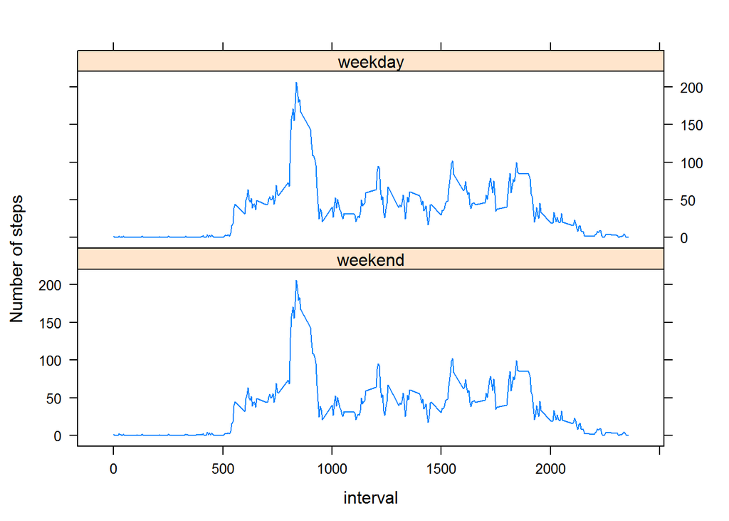

```r
library(lattice)
xyplot(steps.mean ~ interval | wday, data=newactivity,  type="l", layout = c(1,2), ylab = "Number of steps")
```